# relatorio_grupo6

2025-03-22

```r
# Lista de pacotes necessários
packages <- c("cBioPortalData", "MultiAssayExperiment", "SummarizedExperiment",
              "dplyr", "openxlsx", "ggplot2", "FSA", "ggpubr", "lmtest")

# Verificar e instalar pacotes que faltam
new_packages <- packages[!(packages %in% installed.packages()[,"Package"])]
if(length(new_packages)) install.packages(new_packages)

# Instalar pacotes Bioconductor
if (!requireNamespace("BiocManager", quietly = TRUE)) {
    install.packages("BiocManager")
}

# Instalar pacotes do Bioconductor se necessário
bioc_packages <- c("cBioPortalData", "SummarizedExperiment")
for (pkg in bioc_packages) {
    if (!requireNamespace(pkg, quietly = TRUE)) {
        BiocManager::install(pkg)
    }
}

# Carregar pacotes
lapply(packages, library, character.only = TRUE)
```

```
## ## FSA v0.9.6. See citation('FSA') if used in publication.
## ## Run fishR() for related website and fishR('IFAR') for related book.
```

[output not shown]

[output cut: 78 more lines]

```r
# Download do dataset KIRC (Kidney Renal Clear Cell Carcinoma TCGA)
kirc_pack <- cBioDataPack("kirc_tcga")

# Resumo dos dados carregados
summary(kirc_pack)
```

```
##               Length                Class                 Mode
##                   14 MultiAssayExperiment                   S4
```

```r
# Confirmar nomes exatos dos experimentos disponíveis
names(experiments(kirc_pack))
```

```
##  [1] "cna"
##  [2] "cna_hg19.seg"
##  [3] "linear_cna"
##  [4] "methylation_hm27"
##  [5] "methylation_hm450"
##  [6] "mrna_agilent_microarray"
##  [7] "mrna_agilent_microarray_zscores_ref_all_samples"
##  [8] "mrna_agilent_microarray_zscores_ref_diploid_samples"
##  [9] "mrna_seq_v2_rsem"
## [10] "mrna_seq_v2_rsem_zscores_ref_all_samples"
## [11] "mrna_seq_v2_rsem_zscores_ref_diploid_samples"
## [12] "mutations"
## [13] "rppa"
## [14] "rppa_zscores"
```

```r
# Carregar corretamente os dados de expressão génica (RNA-seq)
rna_data <- assay(kirc_pack, "mrna_seq_v2_rsem")

# Carregar dados clínicos
clinical_data <- colData(kirc_pack) %>% as.data.frame()

# Verificar rapidamente os dados carregados
dim(rna_data)
```

```
## [1] 20531   534
```

```r
head(rna_data[, 1:5])
```

```
##              TCGA-3Z-A93Z-01 TCGA-6D-AA2E-01 TCGA-A3-3306-01 TCGA-A3-3307-01
## LOC100130426          0.0000          0.0000          0.0000          0.0000
## UBE2Q2P3              2.9608          2.4501          3.2246          1.8578
## UBE2Q2P3             11.4669          2.4069          8.1625          4.1055
## HMGB1P1              75.7771         49.6384         70.2692         94.6101
## TIMM23              563.9369       1313.5456        601.9669        546.3303
## MOXD2                 0.0000          0.0000          0.0000          0.0000
##              TCGA-A3-3308-01
## LOC100130426          0.0000
## UBE2Q2P3              6.4640
## UBE2Q2P3              2.7113
## HMGB1P1              89.7213
## TIMM23              721.6424
## MOXD2                 0.0000
```

```r
dim(clinical_data)
```

```
## [1] 538  86
```

```r
head(clinical_data)
```

[output not shown]

[output cut: 190 more lines]

```
## TCGA-A3-3311                       YES [Not Available] [Not Available]
##              TARGETED_MOLECULAR_THERAPY TISSUE_SOURCE_SITE SITE_OF_TUMOR_TISSUE
## TCGA-3Z-A93Z                         NO                 3Z               Kidney
## TCGA-6D-AA2E                         NO                 6D               Kidney
## TCGA-A3-3306            [Not Available]                 A3               Kidney
## TCGA-A3-3307            [Not Available]                 A3               Kidney
## TCGA-A3-3308            [Not Available]                 A3               Kidney
## TCGA-A3-3311            [Not Available]                 A3               Kidney
##               OS_STATUS OS_MONTHS      DFS_STATUS      DFS_MONTHS
## TCGA-3Z-A93Z   0:LIVING     12.65   0:DiseaseFree           12.65
## TCGA-6D-AA2E   0:LIVING     11.89   0:DiseaseFree           11.89
## TCGA-A3-3306   0:LIVING     36.79   0:DiseaseFree           36.79
## TCGA-A3-3307   0:LIVING     47.17   0:DiseaseFree           47.17
## TCGA-A3-3308   0:LIVING      0.53   0:DiseaseFree            0.53
## TCGA-A3-3311 1:DECEASED     39.13 [Not Available] [Not Available]
```

## Análise inicial dos dados

Nesta fase procedeu-se à exploração inicial dos dados de forma a perceber a dimensão dos dados correspondentes à expressão genética bem como dos metadados.

#criar ficheiro xlsx para analise em python

write.xlsx(linhas_metadados, “linhas_metadados.xlsx”)

write.xlsx(clinical_data, “amostras_metadados.xlsx”)

```
## Class of kirc_pack: MultiAssayExperiment
```

```
## Class of rna_data: matrix array
```

```
## Dimensions of rna_data: 20531 x 534
```

```
## First 5 column names of rna_data: TCGA-3Z-A93Z-01, TCGA-6D-AA2E-01, TCGA-A3-3306-01, TCGA-A3-3307-01, TCGA-A3-3308-01
```

```
## First 5 row names of rna_data: LOC100130426, UBE2Q2P3, UBE2Q2P3, HMGB1P1, TIMM23
```

```
## Class of linhas_metadados: DFrame
##  Class of amostras_metadados: data.frame
##  Dimensions of linhas_metadados: 20531 x 2
##  Dimensions of amostras_metadados: 534 x 86
##  First 5 column names of linhas_metadados: Hugo_Symbol, Entrez_Gene_Id, NA, NA, NA
##  First 5 column names of amostras_metadados: PATIENT_ID, SAMPLE_ID, OTHER_SAMPLE_ID, SPECIMEN_CURRENT_WEIGHT, DAYS_TO_COLLECTION
```

## 2.3 Preparação e pré-processamento dos dados

Nesta etapa preparamos o dataset para ser, posteriormente, submetido a análise de expressão diferencial e de enriquecimento.

```r
# Extração da matriz de expresrnsão génica
geneExp <- SummarizedExperiment::assay(experiments(kirc_pack)[["mrna_seq_v2_rsem"]])

#transformar em dataframe
geneExp_df <- as.data.frame(geneExp)
```

Com o package **SummarizedExperiment** recorremos ao comando **assay()** para extrair a matriz de expressão do objeto `SummarizedExperiment`. Esta matriz contém os dados numéricos de expressão para cada gene em cada amostra, que são essenciais para análises subsequentes, como normalização, análise de expressão diferencial e análise de enriquecimento.

# 3. Metadados

## 3.1. Pré-processamento e filtragem

Com o intuito de fazer uma filtragem dos metadados, uma vez que é comum a existência de valores omissos, procedeu-se à diminuição do número de colunas associadas aos metadados, eliminando-se as colunas que possuem mais de 10% de valores omissos.

```r
# Remoção de colunas com mais de 10% de valores omissos ou "not Available"
amostras_metadados[amostras_metadados == "[Not Available]"] <- NA

# Calcular a percentagem de valores ausentes por coluna
missing_percent <- colMeans(is.na(amostras_metadados)) * 100

# Manter apenas colunas com menos de 10% de valores ausentes
amostras_metadados_limpo <- amostras_metadados[, missing_percent < 10]

# Verificar o número de colunas antes e depois
cat("Colunas antes da limpeza:", ncol(amostras_metadados), "\n")
```

```
## Colunas antes da limpeza: 86
```

```r
cat("Colunas depois da limpeza:", ncol(amostras_metadados_limpo), "\n")
```

```
## Colunas depois da limpeza: 50
```

Com esta filtragem foi possível diminuir o número de colunas, garantindo que os parâmetros utilizados para posterior análise abrangem a maioria das amostras.

## 3.2. Análise Descritiva e Exploratória

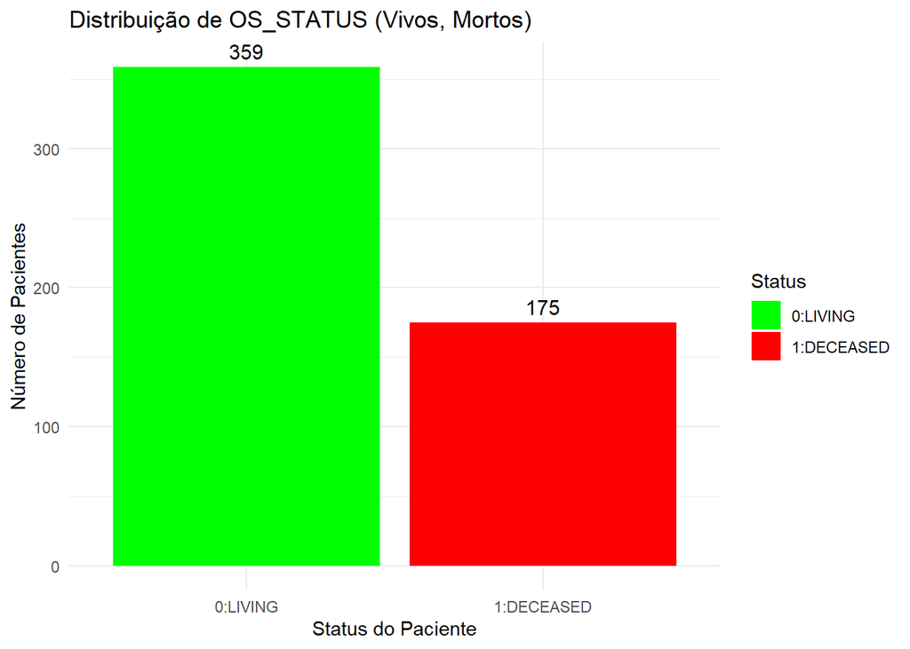

```r
status_counts <- table(amostras_metadados_limpo$OS_STATUS, useNA = "ifany")

# Converter para dataframe para o ggplot
df_status <- as.data.frame(status_counts)
colnames(df_status) <- c("Status", "Count")

# Criar o gráfico de barras
ggplot(df_status, aes(x = Status, y = Count, fill = Status)) +
  geom_bar(stat = "identity") +
  geom_text(aes(label = Count), vjust = -0.5, color = "black", size = 4) +  # Adiciona o número em cima da barra
  theme_minimal() +
  labs(title = "Distribuição de OS_STATUS (Vivos, Mortos)",
       x = "Status do Paciente",
       y = "Número de Pacientes") +
  scale_fill_manual(values = c("0:LIVING" = "green", "1:DECEASED" = "red"))
```

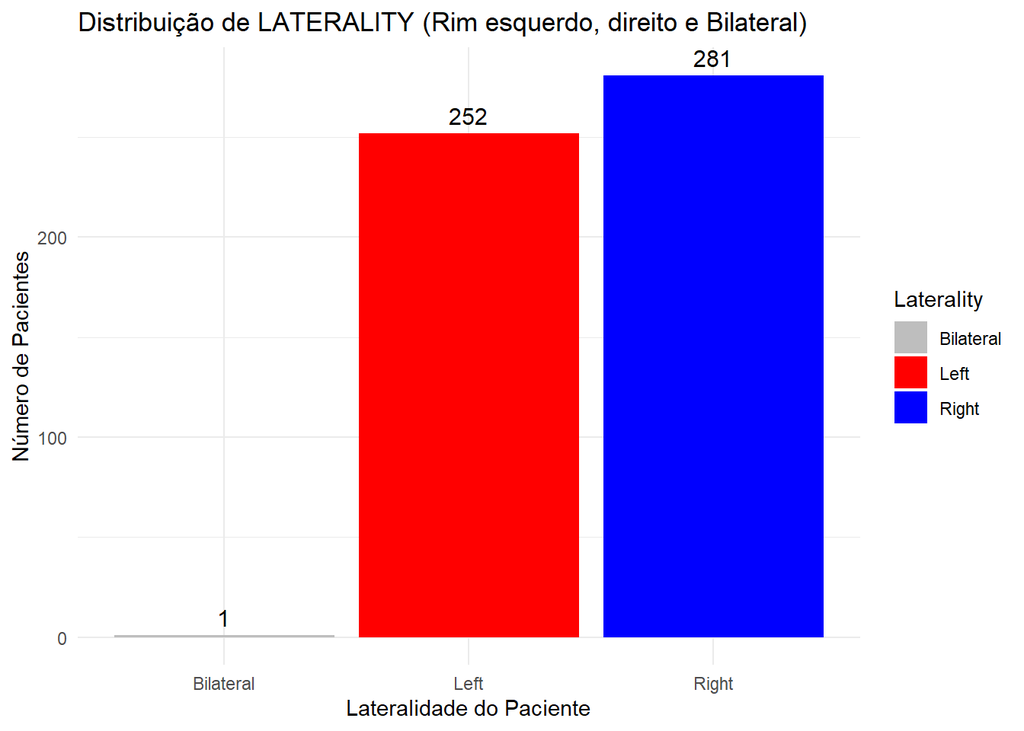

```r
laterality_counts <- table(amostras_metadados_limpo$LATERALITY, useNA = "ifany")

# Converter para dataframe para o ggplot
df_laterality <- as.data.frame(laterality_counts)
colnames(df_laterality) <- c("Laterality", "Count")

# Criar o gráfico de barras
ggplot(df_laterality, aes(x =Laterality, y = Count, fill = Laterality)) +
  geom_bar(stat = "identity") +
  geom_text(aes(label = Count), vjust = -0.5, color = "black", size = 4) +  # Adiciona o número em cima da barra
  theme_minimal() +
  labs(title = "Distribuição de LATERALITY (Rim esquerdo, direito e Bilateral)",
       x = "Lateralidade do Paciente",
       y = "Número de Pacientes") +
  scale_fill_manual(values = c("gray", "red", "blue"))
```

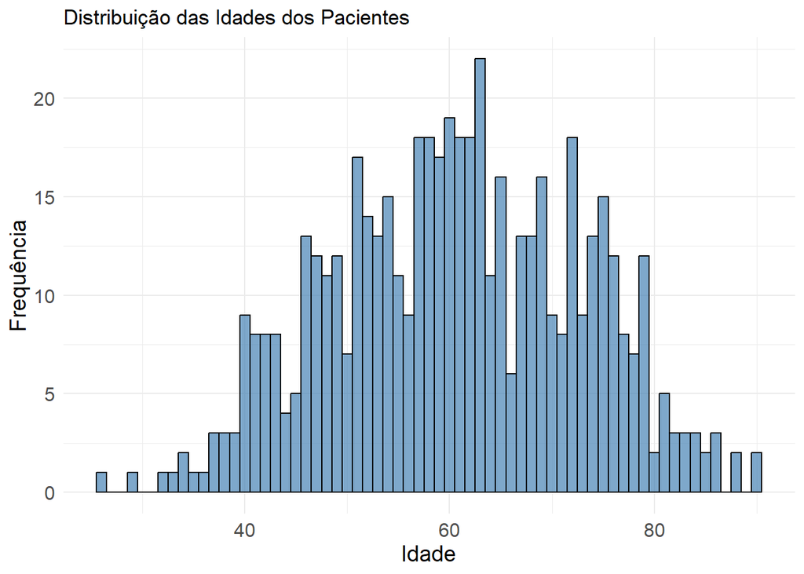

```r
#ajustavel para se perceber melhor a distribuição normal (binwidth=5)
ggplot(amostras_metadados_limpo, aes(x = AGE)) +
  geom_histogram(binwidth = 1, fill = "steelblue", color = "black", alpha = 0.7) +
  theme_minimal() +
  labs(title = "Distribuição das Idades dos Pacientes",
       x = "Idade",
       y = "Frequência") +
  theme(axis.text = element_text(size = 12),
        axis.title = element_text(size = 14))
```

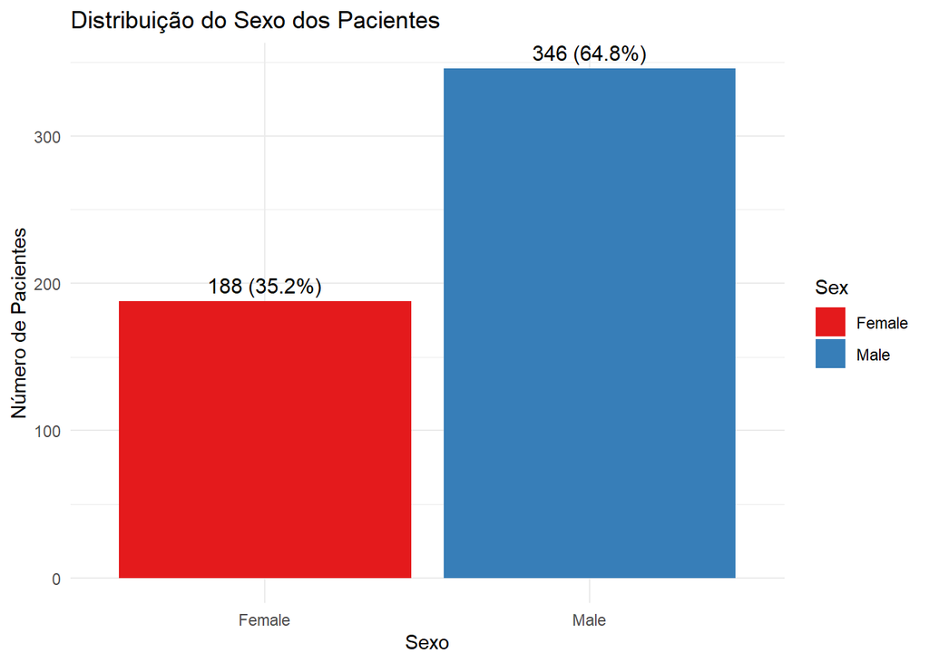

```r
#corrigir o MALE que conta como Male
amostras_metadados_limpo$SEX <- replace(amostras_metadados_limpo$SEX,
                                        amostras_metadados_limpo$SEX == "MALE",
                                        "Male")

sex_counts <- table(amostras_metadados_limpo$SEX, useNA = "ifany")

# Converter para dataframe para usar no ggplot
df_sex <- as.data.frame(sex_counts)
colnames(df_sex) <- c("Sex", "Count")

# Calcular percentagens
df_sex$Percentage <- (df_sex$Count / sum(df_sex$Count)) * 100

# Criar rótulos combinando valores absolutos e percentuais
df_sex$Label <- paste0(df_sex$Count, " (", round(df_sex$Percentage, 1), "%)")

# Criar o gráfico de barras
ggplot(df_sex, aes(x = Sex, y = Count, fill = Sex)) +
  geom_bar(stat = "identity") +
  geom_text(aes(label = Label), vjust = -0.5, color = "black", size = 4) +  # Adiciona rótulos com números e percentagens
  theme_minimal() +
  labs(title = "Distribuição do Sexo dos Pacientes",
       x = "Sexo",
       y = "Número de Pacientes") +
  scale_fill_brewer(palette = "Set1")
```

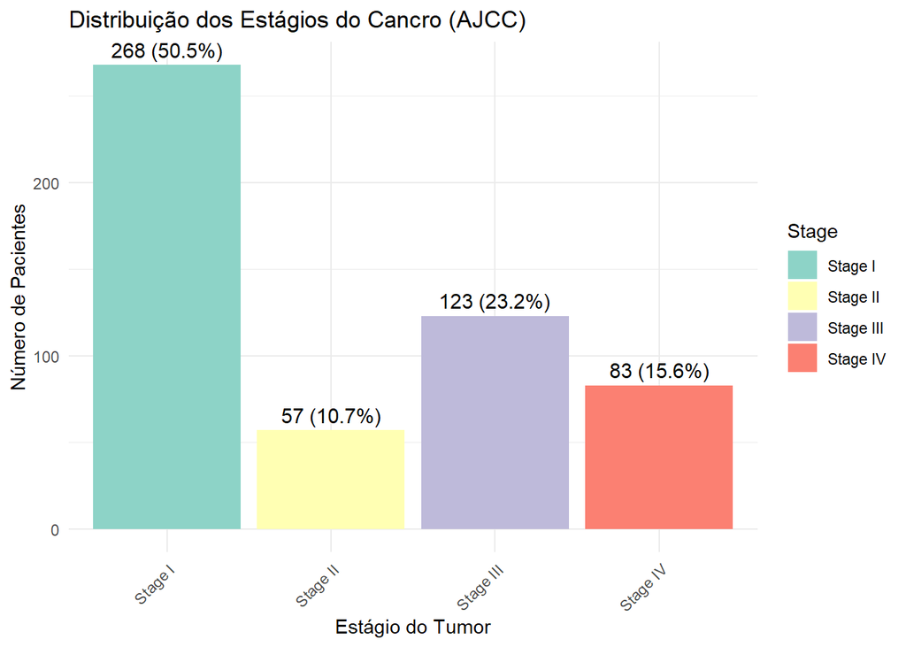

```r
amostras_metadados_limpo <- amostras_metadados_limpo[amostras_metadados_limpo$AJCC_PATHOLOGIC_TUMOR_STAGE %in% c("Stage I", "Stage II", "Stage III", "Stage IV"), ]

stage_counts <- table(amostras_metadados_limpo$AJCC_PATHOLOGIC_TUMOR_STAGE, useNA = "ifany")

# Converter para dataframe para usar no ggplot
df_stage <- as.data.frame(stage_counts)
colnames(df_stage) <- c("Stage", "Count")

# Calcular percentagens
df_stage$Percentage <- (df_stage$Count / sum(df_stage$Count)) * 100

# Criar rótulos combinando valores absolutos e percentagens
df_stage$Label <- paste0(df_stage$Count, " (", round(df_stage$Percentage, 1), "%)")

# Criar o gráfico de barras
ggplot(df_stage, aes(x = Stage, y = Count, fill = Stage)) +
  geom_bar(stat = "identity") +
  geom_text(aes(label = Label), vjust = -0.5, color = "black", size = 4) +  # Adiciona rótulos com números e percentagens
  theme_minimal() +
  labs(title = "Distribuição dos Estágios do Cancro (AJCC)",
       x = "Estágio do Tumor",
       y = "Número de Pacientes") +
  theme(axis.text.x = element_text(angle = 45, hjust = 1)) + # Inclina os rótulos do eixo X para melhor visualização
  scale_fill_brewer(palette = "Set3")
```

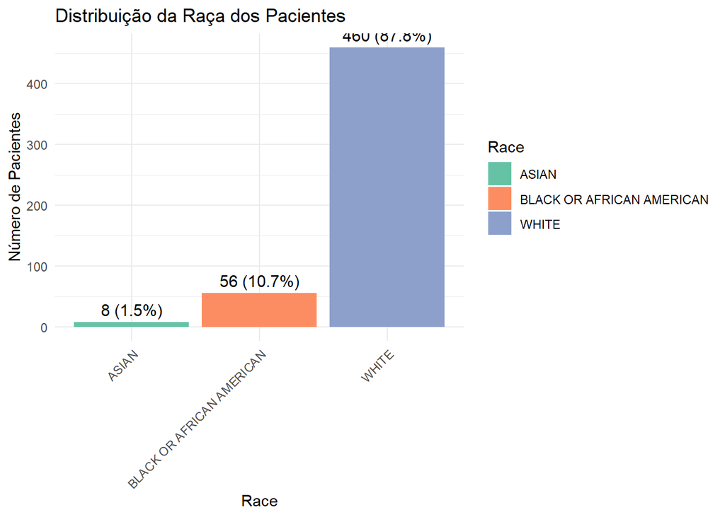

```r
race_counts <- table(amostras_metadados_limpo$RACE)

df_race <- as.data.frame(race_counts)
colnames(df_race) <- c("Race", "Count")

# Calcular percentagens
df_race$Percentage <- (df_race$Count / sum(df_race$Count)) * 100

# Criar rótulos combinando valores absolutos e percentuais
df_race$Label <- paste0(df_race$Count, " (", round(df_race$Percentage, 1), "%)")

# Criar o gráfico de barras
ggplot(df_race, aes(x = Race, y = Count, fill = Race)) +
  geom_bar(stat = "identity") +
  geom_text(aes(label = Label), vjust = -0.5, color = "black", size = 4) +  # Adiciona rótulos com números e percentagens
  theme_minimal() +
  labs(title = "Distribuição da Raça dos Pacientes",
       y = "Número de Pacientes") +
  theme(axis.text.x = element_text(angle = 45, hjust = 1)) + # Inclina os rótulos do eixo X para melhor visualização
  scale_fill_brewer(palette = "Set2")
```

# 4. Testes de Hipótese

## 4.1 Idade por OS_STATUS

```r
# 1. Criar o modelo ANOVA
anova_result <- aov(AGE ~ OS_STATUS, data = amostras_metadados_limpo)

# 2. Obter os resíduos do modelo
residuos <- residuals(anova_result)

# 3. Teste de Shapiro-Wilk (normalidade)
shapiro.test(residuos)
```

```
##
##  Shapiro-Wilk normality test
##
## data:  residuos
## W = 0.99332, p-value = 0.01864
```

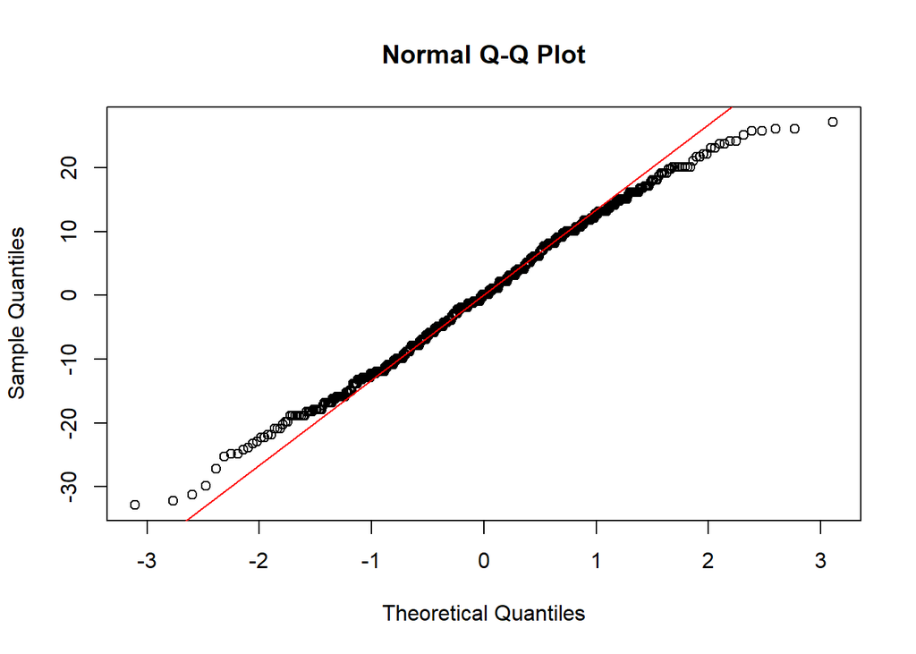

```r
# 4. QQ plot dos resíduos
qqnorm(residuos)
qqline(residuos, col = "red")
```

p-value < 0.05 → rejeitamos a hipótese nula de normalidade dos resíduos. Isso significa que os resíduos não seguem uma distribuição normal Usamos uma teste não parametrico, Mann-Whitney-Wilcoxon.

```r
wilcox.test(AGE ~ OS_STATUS, data = amostras_metadados_limpo)
```

```
##
##  Wilcoxon rank sum test with continuity correction
##
## data:  AGE by OS_STATUS
## W = 23200, p-value = 2.168e-06
## alternative hypothesis: true location shift is not equal to 0
```

O p-value é pequeno (< 0.001).

Há uma diferença estatisticamente significativa entre as distribuições de idade dos pacientes vivos e falecidos.

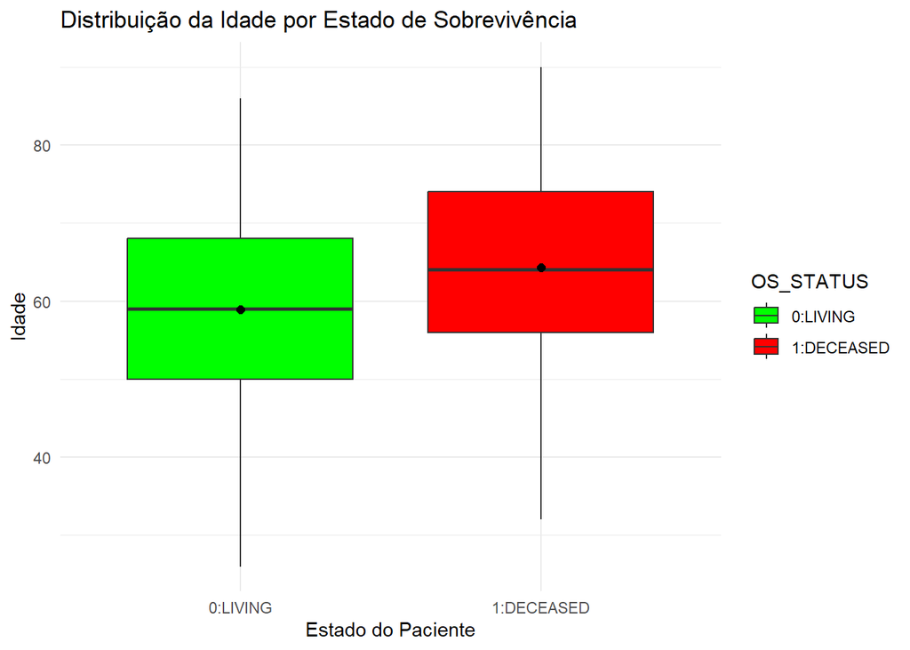

```r
# Remover NAs na idade e status
df_box <- amostras_metadados_limpo %>%
  filter(!is.na(AGE), !is.na(OS_STATUS))

# Criar gráfico de boxplot
ggplot(df_box, aes(x = OS_STATUS, y = AGE, fill = OS_STATUS)) +
  geom_boxplot() +
  theme_minimal() +
  labs(
    title = "Distribuição da Idade por Estado de Sobrevivência",
    x = "Estado do Paciente",
    y = "Idade"
  ) +
  scale_fill_manual(values = c("0:LIVING" = "green", "1:DECEASED" = "red")) +
  stat_summary(fun = mean, geom = "point", shape = 20, size = 3, color = "black", fill = "white")  # ponto da média
```

## 4.2 Idade por estágio de cancro

```r
# Verificar normalidade para cada estágio de câncer
shapiro_test <- by(amostras_metadados_limpo$AGE, amostras_metadados_limpo$AJCC_PATHOLOGIC_TUMOR_STAGE, shapiro.test)
shapiro_test
```

```
## amostras_metadados_limpo$AJCC_PATHOLOGIC_TUMOR_STAGE: Stage I
##
##  Shapiro-Wilk normality test
##
## data:  dd[x, ]
## W = 0.99013, p-value = 0.06641
##
## ------------------------------------------------------------
## amostras_metadados_limpo$AJCC_PATHOLOGIC_TUMOR_STAGE: Stage II
##
##  Shapiro-Wilk normality test
##
## data:  dd[x, ]
## W = 0.96648, p-value = 0.1148
##
## ------------------------------------------------------------
## amostras_metadados_limpo$AJCC_PATHOLOGIC_TUMOR_STAGE: Stage III
##
##  Shapiro-Wilk normality test
##
## data:  dd[x, ]
## W = 0.9745, p-value = 0.01969
##
## ------------------------------------------------------------
## amostras_metadados_limpo$AJCC_PATHOLOGIC_TUMOR_STAGE: Stage IV
##
##  Shapiro-Wilk normality test
##
## data:  dd[x, ]
## W = 0.98941, p-value = 0.737
```

Grupo com distribuição não normal: Stage III (p = 0.01969)

Logo usamos uma alternantiva não parametrica à ANOVA, o teste Kruskal-Wallis.

```r
kruskal.test(AGE ~ AJCC_PATHOLOGIC_TUMOR_STAGE, data = amostras_metadados_limpo)
```

```
##
##  Kruskal-Wallis rank sum test
##
## data:  AGE by AJCC_PATHOLOGIC_TUMOR_STAGE
## Kruskal-Wallis chi-squared = 9.7994, df = 3, p-value = 0.02035
```

O p-value é < 0.05 –> logo rejeitamos a hipotese nula, existe pelo menos uma diferença estatisticamente significativa na idade dos pacientes entre os diferentes estágios de cancro.

Para descobrir quaispares de estágios apresentam diferenças significativas na idade, usamos o dunntest:

```r
dunnTest(AGE ~ AJCC_PATHOLOGIC_TUMOR_STAGE, data = amostras_metadados_limpo, method = "bonferroni")
```

```
##             Comparison           Z     P.unadj      P.adj
## 1   Stage I - Stage II  0.06913039 0.944885833 1.00000000
## 2  Stage I - Stage III -2.99548594 0.002740079 0.01644048
## 3 Stage II - Stage III -2.09898497 0.035818225 0.21490935
## 4   Stage I - Stage IV -0.28332000 0.776931547 1.00000000
## 5  Stage II - Stage IV -0.26550500 0.790620457 1.00000000
## 6 Stage III - Stage IV  2.04610108 0.040746427 0.24447856
```

Os pacientes no estágio III têm, em média, idades significativamente diferentes dos do estágio I.

### Comparações **não significativas**:

Stage I vs Stage II

Stage II vs Stage III

Stage I vs Stage IV

Stage II vs Stage IV

Stage III vs Stage IV

Todas com `p.adj > 0.05`

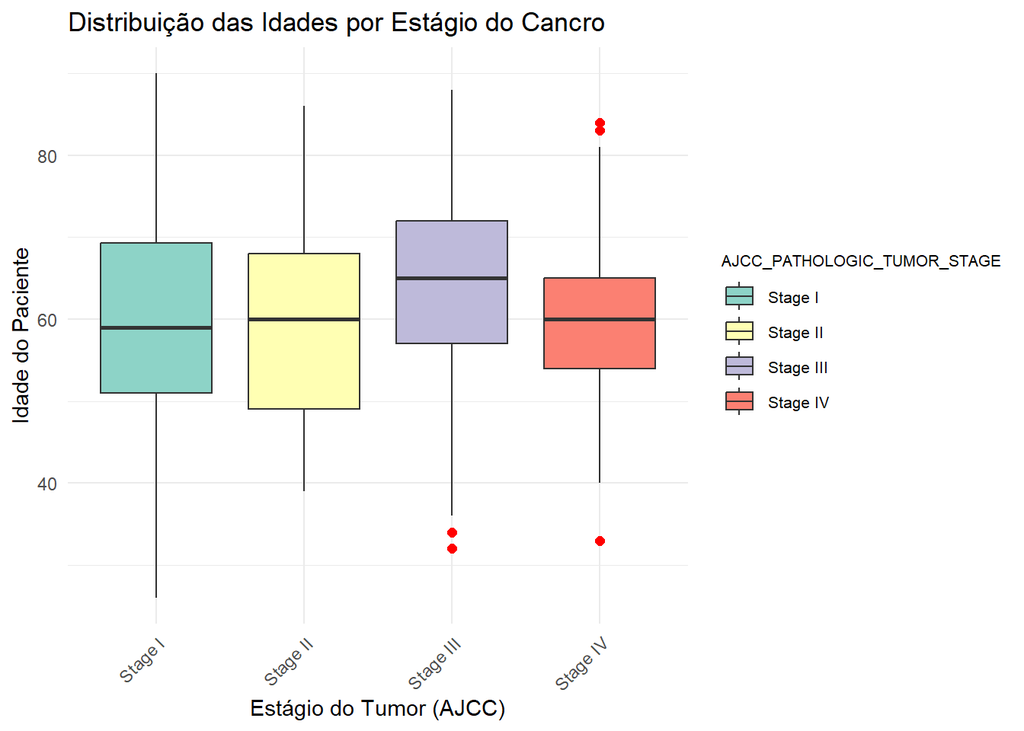

```r
# Boxplot das idades por estágio do cancro
ggplot(amostras_metadados_limpo, aes(x = AJCC_PATHOLOGIC_TUMOR_STAGE, y = AGE, fill = AJCC_PATHOLOGIC_TUMOR_STAGE)) +
  geom_boxplot(outlier.colour = "red", outlier.shape = 16, outlier.size = 2) +
  theme_minimal() +
  labs(title = "Distribuição das Idades por Estágio do Cancro",
       x = "Estágio do Tumor (AJCC)",
       y = "Idade do Paciente") +
  theme(axis.text.x = element_text(angle = 45, hjust = 1),
        legend.title = element_text(size = 8),
        legend.text = element_text(size = 8)) +  # Diminui o texto da legenda
  scale_fill_brewer(palette = "Set3")
```

## 4.3 **Distribuição da sobrevivência (OS_MONTHS)** por **estágio do tumor (AJCC_PATHOLOGIC_TUMOR_STAGE)**

Testar a normalidade

```r
normality_test <- amostras_metadados_limpo %>%
  group_by(AJCC_PATHOLOGIC_TUMOR_STAGE) %>%
  summarise(shapiro_test = list(shapiro.test(OS_MONTHS))) %>%
  mutate(shapiro_p_value = sapply(shapiro_test, function(x) x$p.value))

print(normality_test)
```

```
## # A tibble: 4 × 3
##   AJCC_PATHOLOGIC_TUMOR_STAGE shapiro_test shapiro_p_value
##   <chr>                       <list>                 <dbl>
## 1 Stage I                     <htest>         0.000000623
## 2 Stage II                    <htest>         0.118
## 3 Stage III                   <htest>         0.00000476
## 4 Stage IV                    <htest>         0.0000000913
```

- **Stage I** (p-value = 6.23e-07): Não é normal.
- **Stage II** (p-value = 0.1183): A distribuição é aproximadamente normal.
- **Stage III** (p-value = 4.76e-06): Não é normal.
- **Stage IV** (p-value = 9.13e-08): Não é normal.

Logo usamos um teste não parametrico, o kruskal-Wallis.

```r
kruskal.test(OS_MONTHS ~ AJCC_PATHOLOGIC_TUMOR_STAGE, data = amostras_metadados_limpo)
```

```
##
##  Kruskal-Wallis rank sum test
##
## data:  OS_MONTHS by AJCC_PATHOLOGIC_TUMOR_STAGE
## Kruskal-Wallis chi-squared = 18.604, df = 3, p-value = 0.0003301
```

p-value < 0.05 significa que há diferença significativa entre estagios de grupo em relação a distribuição de sobrevivencia (OS_MONTHS)

Teste de Dunn para identificar quais grupos específicos são significativamente diferentes entre si.

```r
dunnTest(OS_MONTHS ~ AJCC_PATHOLOGIC_TUMOR_STAGE, data = amostras_metadados_limpo, method = "bonferroni")
```

```
##             Comparison         Z      P.unadj       P.adj
## 1   Stage I - Stage II -1.305011 0.1918890969 1.000000000
## 2  Stage I - Stage III  1.518810 0.1288102308 0.772861385
## 3 Stage II - Stage III  2.220315 0.0263973859 0.158384315
## 4   Stage I - Stage IV  3.647793 0.0002645022 0.001587013
## 5  Stage II - Stage IV  3.770258 0.0001630787 0.000978472
## 6 Stage III - Stage IV  2.061310 0.0392734800 0.235640880
```

Comparações significativas:

Stage I vs Stage IV

Stage II vs Stage IV

Comparações não significativas:

Stage I - Stage II

Stage I - Stage III

Stage II - Stage III

Stage III - Stage IV

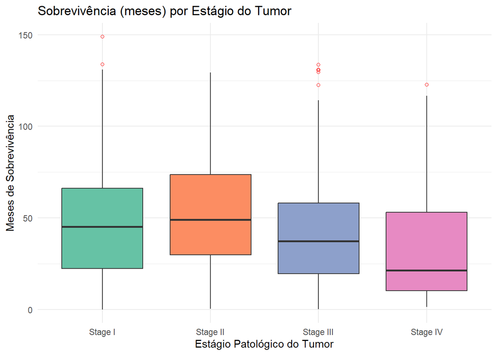

```r
# Garantir que o estágio está como fator e ordenado corretamente (opcional mas melhora visual)
amostras_metadados_limpo$AJCC_PATHOLOGIC_TUMOR_STAGE <- factor(
  amostras_metadados_limpo$AJCC_PATHOLOGIC_TUMOR_STAGE,
  levels = c("Stage I", "Stage II", "Stage III", "Stage IV")
)

# Criar o boxplot
ggplot(amostras_metadados_limpo, aes(x = AJCC_PATHOLOGIC_TUMOR_STAGE, y = OS_MONTHS, fill = AJCC_PATHOLOGIC_TUMOR_STAGE)) +
  geom_boxplot(outlier.color = "red", outlier.shape = 1) +
  theme_minimal() +
  labs(title = "Sobrevivência (meses) por Estágio do Tumor",
       x = "Estágio Patológico do Tumor",
       y = "Meses de Sobrevivência") +
  scale_fill_brewer(palette = "Set2") +
  theme(legend.position = "none")  # Remove legenda se quiseres economizar espaço
```

## 4.4 Proporção de pacientes vivos/mortos por estágio

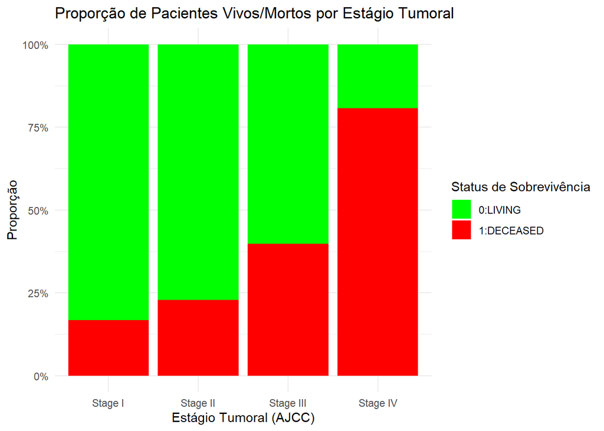

```r
# Verifica se OS_STATUS e AJCC_PATHOLOGIC_TUMOR_STAGE estão como fator
amostras_metadados_limpo$OS_STATUS <- factor(amostras_metadados_limpo$OS_STATUS, levels = c("0:LIVING", "1:DECEASED"))
amostras_metadados_limpo$AJCC_PATHOLOGIC_TUMOR_STAGE <- factor(amostras_metadados_limpo$AJCC_PATHOLOGIC_TUMOR_STAGE)

# Gráfico de barras empilhado em proporção
ggplot(amostras_metadados_limpo, aes(x = AJCC_PATHOLOGIC_TUMOR_STAGE, fill = OS_STATUS)) +
  geom_bar(position = "fill") +
  scale_y_continuous(labels = scales::percent) +
  labs(
    title = "Proporção de Pacientes Vivos/Mortos por Estágio Tumoral",
    x = "Estágio Tumoral (AJCC)",
    y = "Proporção",
    fill = "Status de Sobrevivência"
  ) +
  scale_fill_manual(values = c("0:LIVING" = "green", "1:DECEASED" = "red")) +
  theme_minimal()
```

Teste para ver se o estágio está associado ao status de sobrevivência:

```r
tabela <- table(amostras_metadados_limpo$AJCC_PATHOLOGIC_TUMOR_STAGE, amostras_metadados_limpo$OS_STATUS)

# Teste do Qui-quadrado
chisq.test(tabela)
```

```
##
##  Pearson's Chi-squared test
##
## data:  tabela
## X-squared = 123.05, df = 3, p-value < 2.2e-16
```

Indica que há uma associação estatisticamente significativa entre o estágio do tumor e o status de sobrevivência

## 4.5 Comparação de dimensão do tumor:

### Com o status:

Testar a normalidade

```r
#tranformar em numero
amostras_metadados_limpo$LONGEST_DIMENSION <- as.numeric(as.character(amostras_metadados_limpo$LONGEST_DIMENSION))

grupos_status <- split(amostras_metadados_limpo$LONGEST_DIMENSION, amostras_metadados_limpo$OS_STATUS)
lapply(grupos_status, shapiro.test)
```

```
## $`0:LIVING`
##
##  Shapiro-Wilk normality test
##
## data:  X[[i]]
## W = 0.8805, p-value = 3.028e-15
##
##
## $`1:DECEASED`
##
##  Shapiro-Wilk normality test
##
## data:  X[[i]]
## W = 0.95938, p-value = 7.548e-05
```

Ambos os grupos não têm uma distribuição normal, é mais adequado utilizar testes não paramétricos (Mann-Whitney) para comparar a dimensão do tumor entre os dois grupos (vivos vs. falecidos).

```r
wilcox.test(LONGEST_DIMENSION ~ OS_STATUS, data = amostras_metadados_limpo)
```

```
##
##  Wilcoxon rank sum test with continuity correction
##
## data:  LONGEST_DIMENSION by OS_STATUS
## W = 20117, p-value = 5.041e-07
## alternative hypothesis: true location shift is not equal to 0
```

p-value < 0.05 logo podemos concluir que existe uma diferença estatisticamente significativa entre as dimensões do tumor em pacientes vivos e mortos.

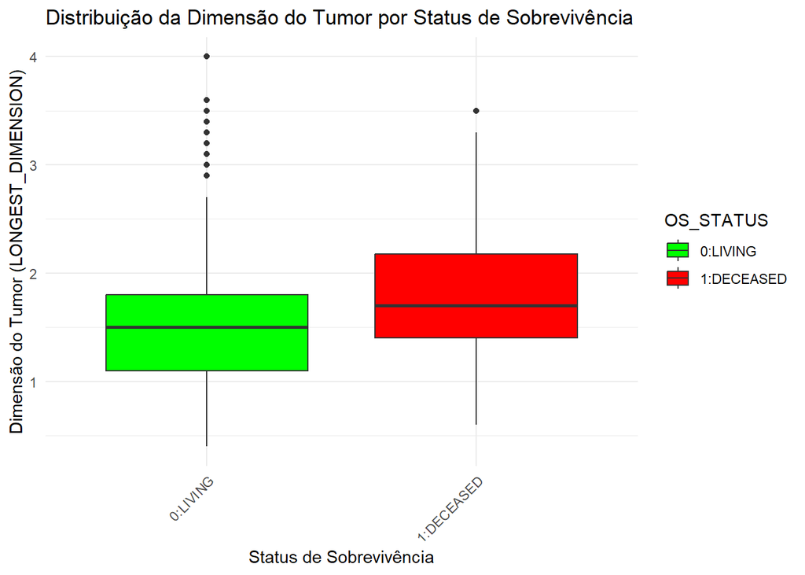

```r
ggplot(amostras_metadados_limpo, aes(x = OS_STATUS, y = LONGEST_DIMENSION, fill = OS_STATUS)) +
  geom_boxplot() +
  scale_fill_manual(values = c("0:LIVING" = "green", "1:DECEASED" = "red")) +  # Definir cores específicas
  labs(title = "Distribuição da Dimensão do Tumor por Status de Sobrevivência",
       x = "Status de Sobrevivência",
       y = "Dimensão do Tumor (LONGEST_DIMENSION)") +
  theme_minimal() +
  theme(axis.text.x = element_text(angle = 45, hjust = 1))
```

### Com o estágio:

Testar a normalidade

```r
grupos_estagio <- split(amostras_metadados_limpo$LONGEST_DIMENSION, amostras_metadados_limpo$AJCC_PATHOLOGIC_TUMOR_STAGE)
lapply(grupos_estagio, shapiro.test)
```

```
## $`Stage I`
##
##  Shapiro-Wilk normality test
##
## data:  X[[i]]
## W = 0.89465, p-value = 5.755e-12
##
##
## $`Stage II`
##
##  Shapiro-Wilk normality test
##
## data:  X[[i]]
## W = 0.91187, p-value = 0.0008414
##
##
## $`Stage III`
##
##  Shapiro-Wilk normality test
##
## data:  X[[i]]
## W = 0.93319, p-value = 1.417e-05
##
##
## $`Stage IV`
##
##  Shapiro-Wilk normality test
##
## data:  X[[i]]
## W = 0.94041, p-value = 0.001013
```

Todos os valores de p são significativamente pequenos (muito abaixo de 0,05), indicando que a normalidade é rejeitada. Logo usamos o teste não parametrico Kruskal.

```r
kruskal.test(LONGEST_DIMENSION ~ AJCC_PATHOLOGIC_TUMOR_STAGE, data = amostras_metadados_limpo)
```

```
##
##  Kruskal-Wallis rank sum test
##
## data:  LONGEST_DIMENSION by AJCC_PATHOLOGIC_TUMOR_STAGE
## Kruskal-Wallis chi-squared = 30.535, df = 3, p-value = 1.065e-06
```

Há uma diferença estatisticamente significativa nas dimensões do tumor (LONGEST_DIMENSION) entre os diferentes estágios do tumor. Para identificar quais estágios específicos diferem entre si usamos o teste de Dunn:

```r
# Remover as linhas com valores ausentes para LONGEST_DIMENSION ou AJCC_PATHOLOGIC_TUMOR_STAGE
amostras_metadados_limpo_sem_na <- amostras_metadados_limpo[!is.na(amostras_metadados_limpo$LONGEST_DIMENSION) & !is.na(amostras_metadados_limpo$AJCC_PATHOLOGIC_TUMOR_STAGE), ]

dunnTest(LONGEST_DIMENSION ~ AJCC_PATHOLOGIC_TUMOR_STAGE, data = amostras_metadados_limpo_sem_na, method = "bonferroni")
```

```
##             Comparison          Z      P.unadj        P.adj
## 1   Stage I - Stage II -1.6570007 9.751934e-02 5.851160e-01
## 2  Stage I - Stage III -3.4285783 6.067515e-04 3.640509e-03
## 3 Stage II - Stage III -0.7919055 4.284158e-01 1.000000e+00
## 4   Stage I - Stage IV -5.1329468 2.852405e-07 1.711443e-06
## 5  Stage II - Stage IV -2.3187759 2.040719e-02 1.224431e-01
## 6 Stage III - Stage IV -1.9447507 5.180499e-02 3.108299e-01
```

Só há diferenças estatisticamente significativas apenas entre Stage I e Stage III/IV.

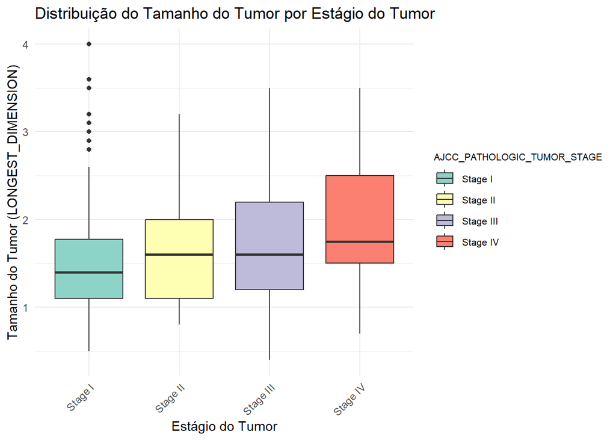

```r
ggplot(amostras_metadados_limpo, aes(x = AJCC_PATHOLOGIC_TUMOR_STAGE, y = LONGEST_DIMENSION, fill = AJCC_PATHOLOGIC_TUMOR_STAGE)) +
  geom_boxplot() +
  labs(title = "Distribuição do Tamanho do Tumor por Estágio do Tumor",
       x = "Estágio do Tumor",
       y = "Tamanho do Tumor (LONGEST_DIMENSION)") +
  scale_fill_brewer(palette = "Set3") +  # Altere a paleta se preferir outras cores
  theme_minimal() +
  theme(axis.text.x = element_text(angle = 45, hjust = 1),  # Inclina os rótulos do eixo X
        legend.text = element_text(size = 8),  # Diminui o tamanho do texto da legenda
        legend.title = element_text(size = 8))  # Diminui o tamanho do título da legenda
```

## 4.6 Correlação entre AGE e OS_MONTHS

testar a normalidade dos residuos

```r
# Verificar NAs e Inf
sum(is.na(amostras_metadados_limpo$OS_MONTHS))  # Contagem de NAs em OS_MONTHS
```

```
## [1] 0
```

```r
sum(is.infinite(amostras_metadados_limpo$OS_MONTHS))  # Contagem de Inf em OS_MONTHS
```

```
## [1] 0
```

```r
sum(amostras_metadados_limpo$OS_MONTHS <= 0, na.rm = TRUE)  # Contagem de valores <= 0 em OS_MONTHS
```

```
## [1] 2
```

```r
# Substituir ou remover valores inválidos
amostras_metadados_limpo <- amostras_metadados_limpo[amostras_metadados_limpo$OS_MONTHS > 0, ]

# Criar o modelo com a transformação log
modelo_log <- lm(log(OS_MONTHS) ~ AGE, data = amostras_metadados_limpo)
summary(modelo_log)
```

```
##
## Call:
## lm(formula = log(OS_MONTHS) ~ AGE, data = amostras_metadados_limpo)
##
## Residuals:
##     Min      1Q  Median      3Q     Max
## -5.8688 -0.5019  0.3203  0.7827  1.6824
##
## Coefficients:
##             Estimate Std. Error t value Pr(>|t|)
## (Intercept)  3.98586    0.26575  14.998   <2e-16 ***
## AGE         -0.01022    0.00430  -2.376   0.0179 *
## ---
## Signif. codes:  0 '***' 0.001 '**' 0.01 '*' 0.05 '.' 0.1 ' ' 1
##
## Residual standard error: 1.198 on 527 degrees of freedom
## Multiple R-squared:  0.0106, Adjusted R-squared:  0.00872
## F-statistic: 5.645 on 1 and 527 DF,  p-value: 0.01786
```

```r
#testar a normalidade
shapiro.test(residuals(modelo_log))
```

```
##
##  Shapiro-Wilk normality test
##
## data:  residuals(modelo_log)
## W = 0.86245, p-value < 2.2e-16
```

```r
#testar se a variância dos resíduos não for constante (heterocedasticidade)
bptest(modelo_log)
```

```
##
##  studentized Breusch-Pagan test
##
## data:  modelo_log
## BP = 6.5015, df = 1, p-value = 0.01078
```

p-value <0.05 sugere que **não há evidências de homocedasticidade** nos resíduos do seu modelo

p-value <0.05 sugere que **os resíduos não seguem uma distribuição normal**.

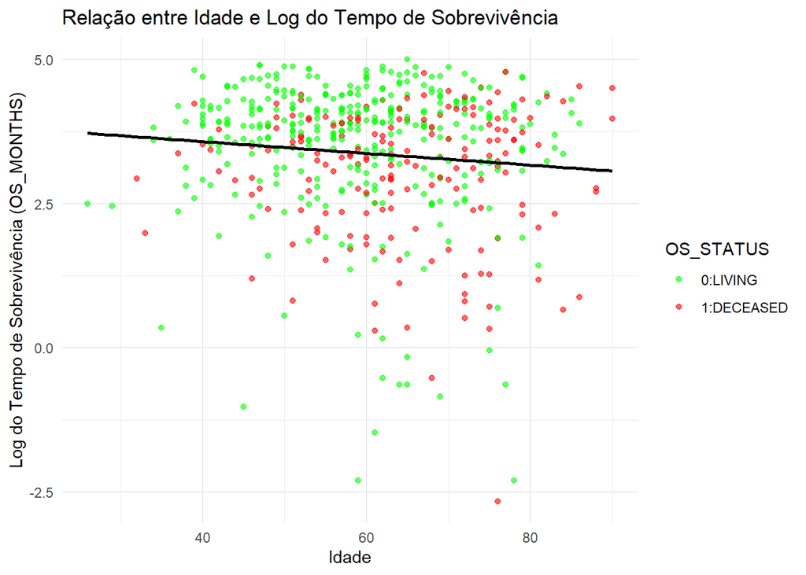

```r
ggplot(amostras_metadados_limpo, aes(x = AGE, y = log(OS_MONTHS), color = OS_STATUS)) +
  geom_point(alpha = 0.6) +  # Plota os pontos
  geom_smooth(method = "lm", se = FALSE, color = "black") +  # Adiciona a linha de regressão
  labs(title = "Relação entre Idade e Log do Tempo de Sobrevivência",
       x = "Idade",
       y = "Log do Tempo de Sobrevivência (OS_MONTHS)") +
  theme_minimal() +
  scale_color_manual(values = c("green", "red"))  # Vivos em verde, falecidos em vermelho
```